# **Modul 7: Text Mining**

Muhammad Apriandito - Digital Business Experience

### **Reading Material**

Please read the following materials.

1. : [Text Mining with R](https://www.tidytextmining.com/)
2. An Introduction to Text Mining: Research Design, Data Collection, and Analysis - Gabe Ignatow and Rada Mihalcea

### **Pretest**

Based on the reading materials, please answer the following questions and submit it via google classroom before the class starts.

1. What is Text Mining?
2. Mention at least 2 text mining techniques
3. Mention at least 3 examples of the implementation of Text Mining in the business field

### **Case: SAMSUNG**

Samsung, South Korean company that is one of the world’s largest producers of electronic devices. Samsung specializes in the production of a wide variety of consumer and industry electronics, including appliances, digital media devices, semiconductors, memory chips, and integrated systems. Sebagai perusahan besar, Samsung ingin mengetahui bagaiamana perspektif warganet di media sosial tentang Sasmsung.

### **Text Mining**

Text mining (also known as text analysis), is the process of transforming unstructured text into structured data for easy analysis. Text mining uses natural language processing (NLP), allowing machines to understand the human language and process it automatically. Text mining is widely used to analyze social media content.

#### **Setup**

First of all, install and load the required packages.

```r
# Install Rtweet Package
install.packages("rtweet")
```

```r
# Load Package
library(tidyverse)
library(ggwordcloud)
library(textclean)
library(tidytext)
```

```r
# Import Data
tweet <- read_rds("data/tweet-samsung.rds")
```

```r
# Show data
head(tweet)
```

| user_id | status_id | created_at | screen_name | text | source | display_text_width | reply_to_status_id | reply_to_user_id | reply_to_screen_name | is_quote | is_retweet | favorite_count | retweet_count | quote_count | reply_count | hashtags | symbols | urls_url | urls_t.co | urls_expanded_url | media_url | media_t.co | media_expanded_url | media_type | ext_media_url | ext_media_t.co | ext_media_expanded_url | ext_media_type | mentions_user_id | … |
| --- | --- | --- | --- | --- | --- | --- | --- | --- | --- | --- | --- | --- | --- | --- | --- | --- | --- | --- | --- | --- | --- | --- | --- | --- | --- | --- | --- | --- | --- | --- |
| 1129208038756237312 | 1396115125589868549 | 2021-05-22 14:45:59 | IshanWankhade | @Agrawalji_Tech @IAM__PRINCERAY @AtulBazaar @Samsung No 1 is nothing in front of customer \nBuyers give profit and loss to brand | Twitter for Android | 77 | 1396111750831828994 | 1102396754710806528 | Agrawalji_Tech | FALSE | FALSE | 0 | 0 | NA | NA |  |  |  |  |  |  |  |  |  |  |  |  | NA |  | … |
| 1356329969828421637 | 1396115100642201601 | 2021-05-22 14:45:53 | hazzlts | @SamsungBrasil samsung você tem falado com a apple? pede pra ela criar um twitter quero ser bestie dela | Twitter for iPhone | 88 | 1396114950968459272 | 59922837 | SamsungBrasil | FALSE | FALSE | 0 | 0 | NA | NA |  |  |  |  |  |  |  |  |  |  |  |  | NA |  | … |
| 202722207 | 1396115086473793540 | 2021-05-22 14:45:49 | NiceNice38 | Moderna samsung biologics https://t.co/BLga9s9WoO | Twitter Web App | 95 | NA | NA | NA | FALSE | TRUE | 0 | 62 | NA | NA |  |  |  |  |  |  |  |  |  |  |  |  | NA |  | … |
| 59922837 | 1396115084385177604 | 2021-05-22 14:45:49 | SamsungBrasil | @Gabriel32931866 Sei que a ansiedade tá grande, biel, por isso, recomendo que você entre na comunidade Samsung Members. Lá nas notificações (o sino que fica na parte superior direita) estará disponíve… | Keepcon Platform | 243 | 1396107634831462403 | 1396067618709254148 | Gabriel32931866 | FALSE | FALSE | 0 | 0 | NA | NA |  |  |  |  |  |  |  |  |  |  |  |  | NA |  | … |
| 59922837 | 1395864340339769348 | 2021-05-21 22:09:27 | SamsungBrasil | @Nacristina_15 Poxa, Tina! Espero que as coisas melhorem. Caso esteja procurando um novo emprego não custa nada olhar as vagas disponíveis no meu site: https://t.co/YU0f8eGtaw | Keepcon Platform | 162 | 1395761711161004037 | 1184280951196700674 | Nacristina_15 | FALSE | FALSE | 0 | 0 | NA | NA |  |  |  |  |  |  |  |  |  |  |  |  | NA |  | … |
| 59922837 | 1396086532797345796 | 2021-05-22 12:52:22 | SamsungBrasil | @VitoVitoito Vito, meu amor! Corre aqui, depois: https://t.co/YU0f8eGtaw e boa sorte! | Keepcon Platform | 75 | 1395924386377572361 | 821166363121225729 | VitoVitoito | FALSE | FALSE | 0 | 0 | NA | NA |  |  |  |  |  |  |  |  |  |  |  |  | NA |  | … |

```r
# Filter Tweet
tweet_en <- tweet %>%
  filter(lang == "en")
```

```r
# Show Filtered Tweet
head(tweet_en)
```

| user_id | status_id | created_at | screen_name | text | source | display_text_width | reply_to_status_id | reply_to_user_id | reply_to_screen_name | is_quote | is_retweet | favorite_count | retweet_count | quote_count | reply_count | hashtags | symbols | urls_url | urls_t.co | urls_expanded_url | media_url | media_t.co | media_expanded_url | media_type | ext_media_url | ext_media_t.co | ext_media_expanded_url | ext_media_type | mentions_user_id | … |
| --- | --- | --- | --- | --- | --- | --- | --- | --- | --- | --- | --- | --- | --- | --- | --- | --- | --- | --- | --- | --- | --- | --- | --- | --- | --- | --- | --- | --- | --- | --- |
| 1129208038756237312 | 1396115125589868549 | 2021-05-22 14:45:59 | IshanWankhade | @Agrawalji_Tech @IAM__PRINCERAY @AtulBazaar @Samsung No 1 is nothing in front of customer \nBuyers give profit and loss to brand | Twitter for Android | 77 | 1396111750831828994 | 1102396754710806528 | Agrawalji_Tech | FALSE | FALSE | 0 | 0 | NA | NA |  |  |  |  |  |  |  |  |  |  |  |  | NA |  | … |
| 803987160 | 1396113309196177413 | 2021-05-22 14:38:46 | Ankit2Awesome | I uploaded a new video\ncheck it out here\nUdrawat: Samsung Crystal 4K Pro 2021 Model 50 Inch LED TV FULL REVIEW \|\| Samsung AUE60/AUE70/AU8000 https://t.co/VQJlvzwfHw | Twitter Web App | 140 | NA | NA | NA | FALSE | TRUE | 0 | 2 | NA | NA |  |  |  |  |  |  |  |  |  |  |  |  | NA |  | … |
| 803987160 | 1396113354012327936 | 2021-05-22 14:38:56 | Ankit2Awesome | I uploaded a new video\ncheck it out here\nUdrawat: Samsung Crystal 4K Pro 2021 Model 50 Inch LED TV Unboxing and Giveaway \|\| Samsung AUE60/AUE70/AU8000 https://t.co/x2ChXld0BW | Twitter Web App | 140 | NA | NA | NA | FALSE | TRUE | 0 | 6 | NA | NA |  |  |  |  |  |  |  |  |  |  |  |  | NA |  | … |
| 803987160 | 1396115044140666880 | 2021-05-22 14:45:39 | Ankit2Awesome | Samsung Crystal 4K Pro 2021 Model 50 Inch LED TV Unboxing and Giveaway \|... https://t.co/QTzBeClD5Q via @YouTube \n@AmitVerma904 @patilist @chiragtiwari161 @rajeshsingh7667 @mr_kurkure | Twitter Web App | 184 | NA | NA | NA | FALSE | FALSE | 0 | 0 | NA | NA |  |  |  |  |  |  |  |  |  |  |  |  | NA |  | … |
| 1373815865410416641 | 1396115017972420609 | 2021-05-22 14:45:33 | AOMGH1GHR__ID | 210522 GRAY’s update\n\n1. Proof of true samsung notebook user\n\n2. Even when in YHY sketchbook~\n\n3. During our recent ‘Comeback Home’\n\n4. As the result, got an ad~ oh yeah\n\n#GRAY #AOMG https:/… | Twitter for iPhone | 184 | NA | NA | NA | FALSE | FALSE | 1 | 0 | NA | NA |  |  |  |  |  |  |  |  |  |  |  |  | NA |  | … |
| 1373815865410416641 | 1395965915343118343 | 2021-05-22 04:53:04 | AOMGH1GHR__ID | Samsung Galaxy Book Event Live Highlight \n: https://t.co/gUCV8hWJys ( VPN required )\nFull live clip : https://t.co/EEnWcPlTKn ©@Graygent_ \n# #GRAY #AOMG #Solar #Mamamoo # #GrayxGalaxyBookEvent http… | Twitter for Android | 140 | NA | NA | NA | FALSE | TRUE | 0 | 9 | NA | NA |  |  |  |  |  |  |  |  |  |  |  |  | NA |  | … |

#### **Wordcloud Visualization**

The first analysis that can be done is the wordcloud visualization. Word clouds (also known as text clouds or tag clouds) work in a simple way: the more a specific word appears in a source of textual data (such as a speech, blog post, or database), the bigger and bolder it appears in the word cloud. Wordcloud helps us see what the conversation is about in general.

```r
# Text Preprocessing
text <- tweet_en %>%
  select(text) %>%
  mutate(text = strip(text)) %>%
  mutate(text = replace_emoji(text)) %>%
  mutate(text = replace_html(text)) %>%
  mutate(text = replace_hash(text, pattern = "#([A-Za-z0-9_]+)", replacement = "")) %>%
  mutate(text = replace_tag(text, pattern = "@([A-Za-z0-9_]+)", replacement = "")) %>%
  unnest_tokens(word, text) %>%
  anti_join(stop_words) %>%
  anti_join(custom_stopwords)
head(text)
```

| word |
| --- |
| agrawaljitech |
| iamprinceray |
| atulbazaar |
| samsung |
| front |
| customer |

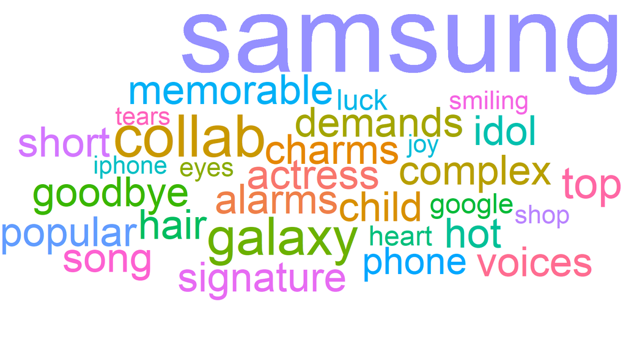

```r
# Wordcloud Visuzation
text %>%
  count(word) %>%
  filter(n > 400) %>%
  ggplot(aes(label = word, size = n, colour = word)) +
  geom_text_wordcloud() +
  scale_size_area(max_size = 40) +
  theme_void()
```

Based on the results of the visualization above, there are several words related to Google and iPhone.

#### **Sentiment Analysis**

The next analysis that can be done is sentiment analysis. Sentiment analysis (or opinion mining) is a Text Miningtechnique used to determine whether data is positive, negative or neutral.

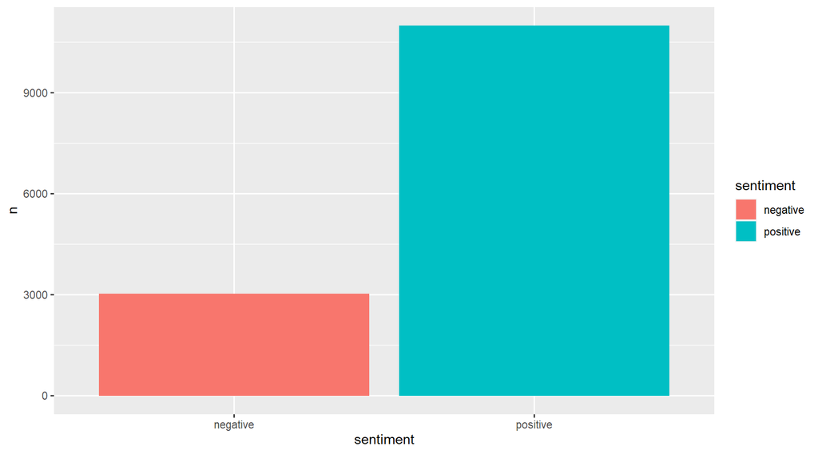

```r
text %>%
  inner_join(get_sentiments("bing")) %>%
  group_by(sentiment) %>%
  count() %>%
  ggplot(aes(x = sentiment, y = n, fill = sentiment)) +
  geom_col() +
  scale_fill_manual(values = c("#f8766d", "#00bfc4"))
```

### **Conclusion**

Social media conversation content can be analyzed using text mining

### Post Test

1. Collect twitter conversation data related to a well-known brand that you like
2. Analyze the sentiment
3. Interpret the result